# Wedding_Planner

Wedding Planner Event

**Authored by: Samarth Shah**

**Duration:** 90 mins

**Level:** Intermediate

**Pre-requisite Skills:** Python, NumPy, Pandas, Matplotlib, Seaborn, Folium

**Scenario**

As a wedding planner, I want to identify suitable wedding venues in Melbourne, understand the necessary permits, and locate photogenic areas for wedding photos, so I can provide personalized recommendations to clients and ensure a smooth planning process.

**What this use case will teach you**

At the end of this use case you will:

- Data wrangling and preprocessing
- Geospatial analysis and mapping
- Data visualization
- Wedding industry knowledge

**Introduction or background relating to problem**

Melbourne is a popular destination for weddings, with numerous venues offering unique settings and backdrops. However, finding the perfect venue can be overwhelming, especially when considering factors like permits, photography opportunities, and previous wedding events. This use case aims to leverage data science techniques to streamline the wedding planning process, providing valuable insights for wedding planners and clients alike.

**Background** To solve this problem, we will utilize the following datasets:

- Event Permits (2014-2018): This dataset contains information on event permits issued by the City of Melbourne, including weddings, film shoots, and photo shoots. (https://data.melbourne.vic.gov.au/explore/dataset/event-permits-2014-2018-including-film-shoots-photo-shoots-weddings-christmas-pa/information/)
- Outdoor Artworks: This dataset features information on outdoor artworks in Melbourne, which can serve as photogenic backdrops for wedding photos. (https://data.melbourne.vic.gov.au/explore/dataset/outdoor-artworks/information/

- Public Artworks, Fountains, and Monuments: This dataset provides information on public artworks, fountains, and monuments in Melbourne, offering additional photography opportunities. (https://data.melbourne.vic.gov.au/explore/dataset/public-artworks-fountains-and-monuments/information/)

### 1.Importing required libraries

```python
pip install requests pandas matplotlib seaborn folium
```

I’ve imported these libraries to handle different tasks in the project. I’m using requests to retrieve data from web APIs, while pandas helps me organize and process that data into dataframes. For visualizing the data, I’m using matplotlib.pyplot to create charts and graphs, and seaborn makes statistical plotting easier and more visually appealing. Lastly, folium allows me to create interactive maps, which is useful for visualizing any geographical data I might have. Together, these libraries make it easier to manage, analyze, and present the data effectively.

```python
import requests
import pandas as pd
import matplotlib.pyplot as plt
import seaborn as sns
import folium
```

I’m downloading three datasets from the City of Melbourne’s open data API. The first dataset contains event permits from 2014-2018, including film shoots, photo shoots, and weddings; the second contains information about outdoor artworks; and the third is about public artworks, fountains, and monuments. I’ve created a function called download_data that takes the API URL, sends a request to retrieve the data, and then converts the response (in JSON format) into a pandas DataFrame for easier analysis. After downloading each dataset using this function, I print the first few rows of each DataFrame to get a quick view of the data. This allows me to easily access and explore the information in these datasets.

```python
# URLs for the datasets
url1 = "https://data.melbourne.vic.gov.au/api/explore/v2.1/catalog/datasets/event-permits-2014-2018-including-film-shoots-photo-shoots-weddings-christmas-pa/records?limit=-1"
url2 = "https://data.melbourne.vic.gov.au/api/explore/v2.1/catalog/datasets/outdoor-artworks/records?limit=-1"
url3 = "https://data.melbourne.vic.gov.au/api/explore/v2.1/catalog/datasets/public-artworks-fountains-and-monuments/records?limit=-1"

# Function to download and convert to DataFrame
def download_data(link):
    response = requests.get(link)
    response.raise_for_status()
    data = response.json()
    records = data['results']
    return pd.DataFrame(records)

# Download the datasets
df_permits = download_data(url1)
df_artworks = download_data(url2)
df_public_artworks = download_data(url3)

# Display the first few rows of each dataset
print("Event Permits:\n", df_permits.head(), "\n")
print("Outdoor Artworks:\n", df_artworks.head(), "\n")
print("Public Artworks, Fountains, and Monuments:\n", df_public_artworks.head(), "\n")
```

```
Event Permits:
                   title event_start   event_end       category_1  \
0  The Moon And The Sun  2014-05-05  2014-05-10  Filming - Movie
1       Childhood's End  2014-12-04  2014-12-04  Filming - Movie
2       Childhood's End  2014-12-09  2014-12-10  Filming - Movie
3              Dogfight  2016-08-28  2016-08-28  Filming - Movie
4              Dogfight  2016-09-10  2016-09-10  Filming - Movie

            category_2                            location
0                 None                   Promotional Sites
1                 None                        Princes Park
2                 None  Little Bourke Street, Rankins Lane
3                 None     Treasury Gardens, Spring Street
4  Filming - Unit Base                Other Park Locations

```

[output cut: 120 more lines]

### 2.Clean and Process the data

Cleaning and preparing the data for analysis by normalizing text, handling missing values, and removing duplicates. First, I created a normalize_text function that strips leading/trailing whitespace and converts text to lowercase in specified columns to maintain consistency. Then, I convert dictionary-like columns (e.g., geo_point_2d, geo_shape, and co_ordinates) to string format so they can be more easily processed. After that, I handle missing values by filling them with the string 'unknown' to avoid errors during analysis. Finally, I remove any duplicate entries to ensure the data is clean and unique. After cleaning the data, I print the first few rows of each dataset to verify the changes.

```python
# Normalize text (e.g., strip leading/trailing whitespace, convert to lowercase)
def normalize_text(df, columns):
    for col in columns:
        df[col] = df[col].str.strip().str.lower()
    return df

df_permits = normalize_text(df_permits, ['title', 'location'])
df_artworks = normalize_text(df_artworks, ['title', 'location'])
df_public_artworks = normalize_text(df_public_artworks, ['name', 'address_point'])

# Convert dict columns to string
df_artworks['geo_point_2d'] = df_artworks['geo_point_2d'].astype(str)
df_artworks['geo_shape'] = df_artworks['geo_shape'].astype(str)
df_public_artworks['co_ordinates'] = df_public_artworks['co_ordinates'].astype(str)

# Handle missing values
df_permits.fillna('unknown', inplace=True)
df_artworks.fillna('unknown', inplace=True)
df_public_artworks.fillna('unknown', inplace=True)

# Remove duplicates
df_permits.drop_duplicates(inplace=True)
df_artworks.drop_duplicates(inplace=True)
df_public_artworks.drop_duplicates(inplace=True)

print("Cleaned Event Permits:\n", df_permits.head(), "\n")
print("Cleaned Outdoor Artworks:\n", df_artworks.head(), "\n")
print("Cleaned Public Artworks, Fountains, and Monuments:\n", df_public_artworks.head(), "\n")
```

```
Cleaned Event Permits:
                   title event_start   event_end       category_1  \
0  the moon and the sun  2014-05-05  2014-05-10  Filming - Movie
1       childhood's end  2014-12-04  2014-12-04  Filming - Movie
2       childhood's end  2014-12-09  2014-12-10  Filming - Movie
3              dogfight  2016-08-28  2016-08-28  Filming - Movie
4              dogfight  2016-09-10  2016-09-10  Filming - Movie

            category_2                            location
0              unknown                   promotional sites
1              unknown                        princes park
2              unknown  little bourke street, rankins lane
3              unknown     treasury gardens, spring street
4  Filming - Unit Base                other park locations

```

[output cut: 120 more lines]

### 3. Analyse the data

In this section, I’m generating summary statistics and analyzing the distribution of events over time. First, I use describe(include='all') to generate summary statistics for each dataset, which provides insights into the overall distribution of data, including categorical and numeric columns. This gives me a sense of things like the range of values, frequency of categories, and the presence of any missing data. Next, I focus on the df_permits dataset and convert the event_start and event_end columns to datetime format using pd.to_datetime(). This is important for any time-based analysis, such as understanding when events occurred or calculating their durations. Once the data is in datetime format, I can easily plot or analyze trends in event permits over time.

```python
# Summary Statistics
print("Event Permits Summary:")
print(df_permits.describe(include='all'))

print("\nOutdoor Artworks Summary:")
print(df_artworks.describe(include='all'))

print("\nPublic Artworks Summary:")
print(df_public_artworks.describe(include='all'))

# Distribution of Events Over Time
df_permits['event_start'] = pd.to_datetime(df_permits['event_start'])
df_permits['event_end'] = pd.to_datetime(df_permits['event_end'])
```

```
Event Permits Summary:
                 title event_start   event_end           category_1  \
count              100         100         100                  100
unique              80          98          98                    7
top     the wrong girl  2014-07-23  2014-12-10  Filming - TV Series
freq                 5           2           2                   52

       category_2                location
count         100                     100
unique          4                      69
top       unknown  inner suburb locations
freq           97                      10

Outdoor Artworks Summary:
                                             geo_point_2d  \
count                                                 100
unique                                                100
top     {'lon': 144.96706152142454, 'lat': -37.8164236...
freq                                                    1
mean                                                  NaN
std                                                   NaN
min                                                   NaN
25%                                                   NaN
50%                                                   NaN
75%                                                   NaN
max                                                   NaN

                                                geo_shape road_segment  \
count                                                 100          100
unique                                                100           19
top     {'type': 'Feature', 'geometry': {'coordinates'...      unknown
freq                                                    1           80
mean                                                  NaN          NaN
std                                                   NaN          NaN
min                                                   NaN          NaN
25%                                                   NaN          NaN
50%                                                   NaN          NaN
75%                                                   NaN          NaN
max                                                   NaN          NaN

```

[output cut: 115 more lines]

```
75%           NaN                                                NaN
max           NaN                                                NaN

              easting      northing
count      100.000000  1.000000e+02
unique            NaN           NaN
top               NaN           NaN
freq              NaN           NaN
mean    320597.927115  5.812824e+06
std       1206.561404  9.891217e+02
min     315771.745000  5.811420e+06
25%     319378.013750  5.812177e+06
50%     320908.012500  5.812680e+06
75%     321595.782650  5.813207e+06
max     323043.869000  5.816762e+06
```

### Displaying the Data

In this step, I’m visualizing the yearly distribution of events. I extract the year from the event_start column, then plot a histogram using seaborn to show the number of events per year. The plot includes a kernel density estimate (KDE) to highlight trends over time, with labels and grid lines for clarity. This helps to quickly see how event permits have varied year by year.

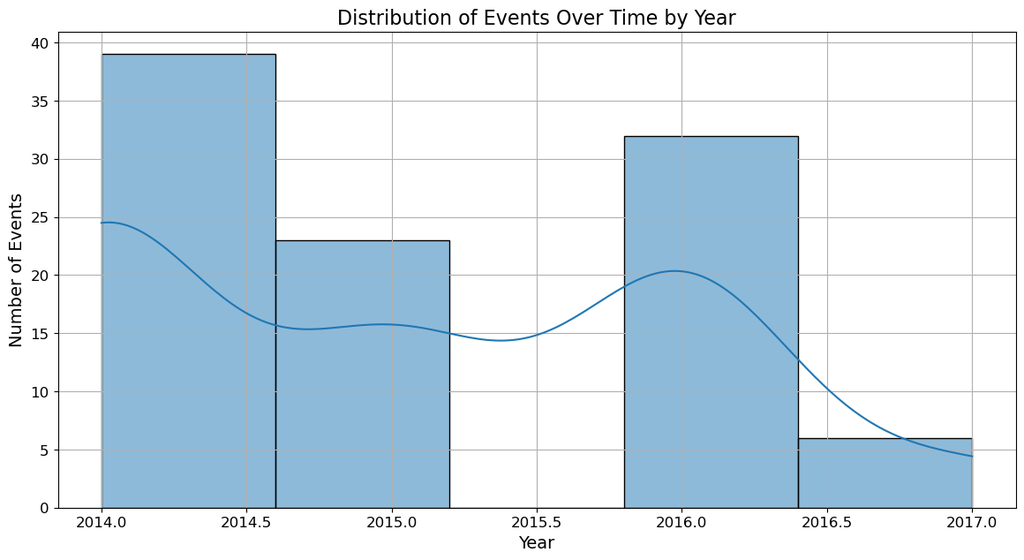

```python
# Distribution of Events Over Time by Year
df_permits['year'] = df_permits['event_start'].dt.year

plt.figure(figsize=(14, 7))
sns.histplot(df_permits['year'], bins=5, kde=True)
plt.title('Distribution of Events Over Time by Year', fontsize=16)
plt.xlabel('Year', fontsize=14)
plt.ylabel('Number of Events', fontsize=14)
plt.xticks(fontsize=12)
plt.yticks(fontsize=12)
plt.grid(True)
plt.show()
```

In this step, I calculate the duration of each event by subtracting the event_start date from the event_end date and storing the result in a new column called event_duration. Then, I visualize the distribution of event durations using a histogram with seaborn, showing how long most events last. The plot includes a kernel density estimate (KDE) to highlight the underlying distribution pattern. This helps in understanding the typical length of events and identifying any outliers or trends in event duration.

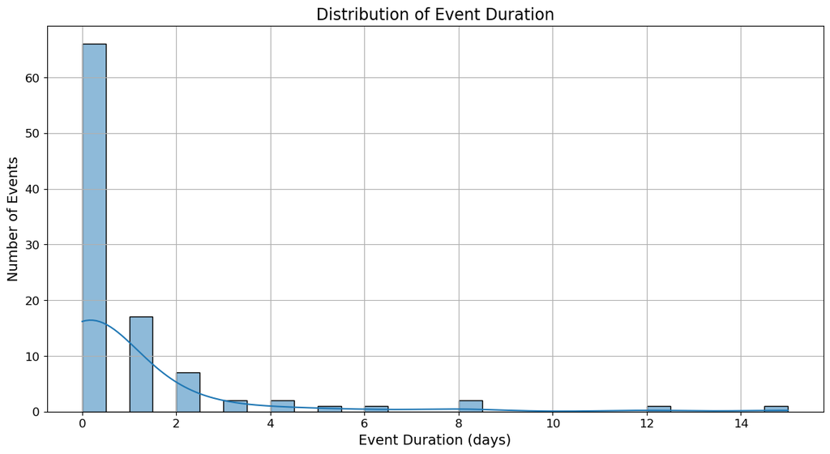

```python
# Calculate event duration
df_permits['event_duration'] = (df_permits['event_end'] - df_permits['event_start']).dt.days

# Distribution of Event Duration
plt.figure(figsize=(14, 7))
sns.histplot(df_permits['event_duration'], bins=30, kde=True)
plt.title('Distribution of Event Duration', fontsize=16)
plt.xlabel('Event Duration (days)', fontsize=14)
plt.ylabel('Number of Events', fontsize=14)
plt.xticks(fontsize=12)
plt.yticks(fontsize=12)
plt.grid(True)
plt.show()
```

### Distribution of Events Based on Location

I identify the top 10 event locations and filter the dataset to include only these locations. Using a seaborn countplot, I visualize the event distribution across these locations, customizing the plot for clarity. This quickly highlights the most popular locations for events.

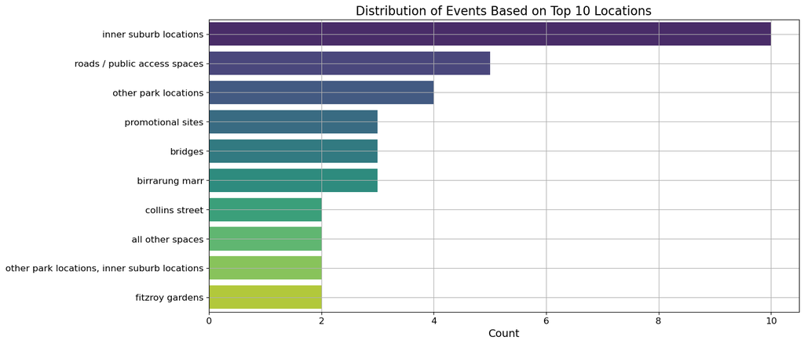

```python
# Get the top 10 locations based on count
top_10_locations = df_permits['location'].value_counts().nlargest(10).index

# Filter the dataframe to include only the top 5 locations
df_top_10_locations = df_permits[df_permits['location'].isin(top_10_locations)]

# Plot
plt.figure(figsize=(14, 7))
sns.countplot(y='location', data=df_top_10_locations, order=top_10_locations, palette='viridis')

# Customize plot
plt.title('Distribution of Events Based on Top 10 Locations', fontsize=16)
plt.xlabel('Count', fontsize=14)
plt.ylabel('')  # Remove y-axis label (Location)
plt.xticks(fontsize=12)
plt.yticks(fontsize=12)  # Remove the y-axis ticks (to hide location names)
plt.grid(True)

# Display the plot
plt.show()
```

### Distribution of events by month

Here, I extract the month from the event_start date and visualize the distribution of events by month using a seaborn countplot. The plot is customized with proper labels, a rotated x-axis for readability, and a color palette. This gives a clear view of how events are distributed throughout the year.

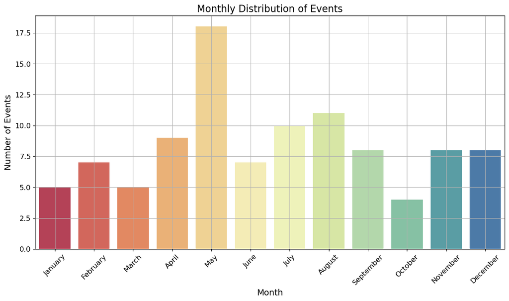

```python
# Extract the month from the event start date
df_permits['month'] = df_permits['event_start'].dt.month_name()

plt.figure(figsize=(14, 7))
sns.countplot(x='month', data=df_permits, order=['January', 'February', 'March', 'April', 'May', 'June',
                                                 'July', 'August', 'September', 'October', 'November', 'December'], palette='Spectral')
plt.title('Monthly Distribution of Events', fontsize=16)
plt.xlabel('Month', fontsize=14)
plt.ylabel('Number of Events', fontsize=14)
plt.xticks(rotation=45, fontsize=12)
plt.yticks(fontsize=12)
plt.grid(True)
plt.show()
```

### Visualize clusters of photogenic areas

In this step, I use the KMeans algorithm to cluster outdoor artworks based on their geographical coordinates (latitude and longitude). I fit the model with 5 clusters and assign each artwork to a cluster. Then, I visualize the clusters using a scatterplot, where each cluster is represented by a different color. This helps in identifying potential photogenic areas for wedding photos by grouping artworks based on their location.

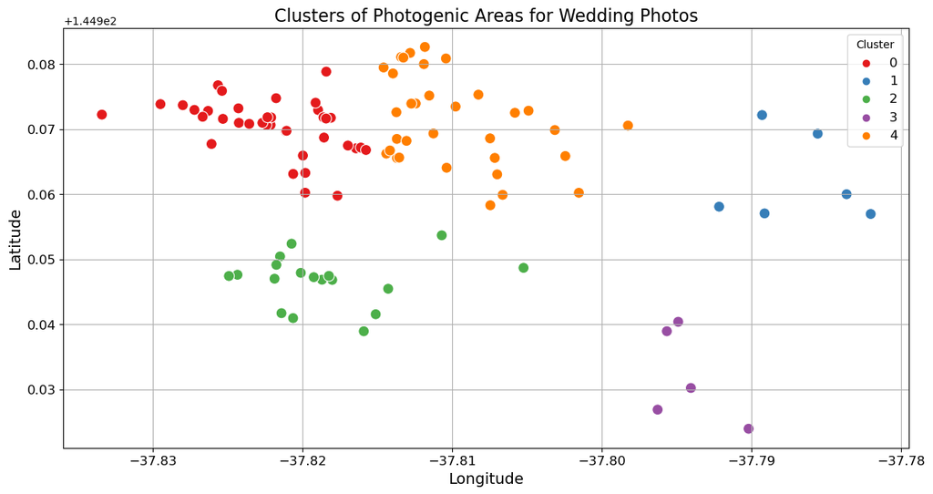

```python
from sklearn.cluster import KMeans

# Use KMeans to identify clusters of artworks
coordinates = df_artworks[['latitude', 'longitude']]
kmeans = KMeans(n_clusters=5, random_state=42).fit(coordinates)
df_artworks['cluster'] = kmeans.labels_

plt.figure(figsize=(14, 7))
sns.scatterplot(x='longitude', y='latitude', hue='cluster', data=df_artworks, palette='Set1', s=100)
plt.title('Clusters of Photogenic Areas for Wedding Photos', fontsize=16)
plt.xlabel('Longitude', fontsize=14)
plt.ylabel('Latitude', fontsize=14)
plt.xticks(fontsize=12)
plt.yticks(fontsize=12)
plt.legend(title='Cluster', fontsize=12)
plt.grid(True)
plt.show()
```

### Pie chart for event categories

In this step, I visualize the distribution of event categories using a pie chart. The chart displays the percentage breakdown of each category, with pastel colors for a clean aesthetic. The autopct argument shows the percentage values, and the y-axis label is removed for a simpler presentation. This helps quickly understand how different event categories are distributed.

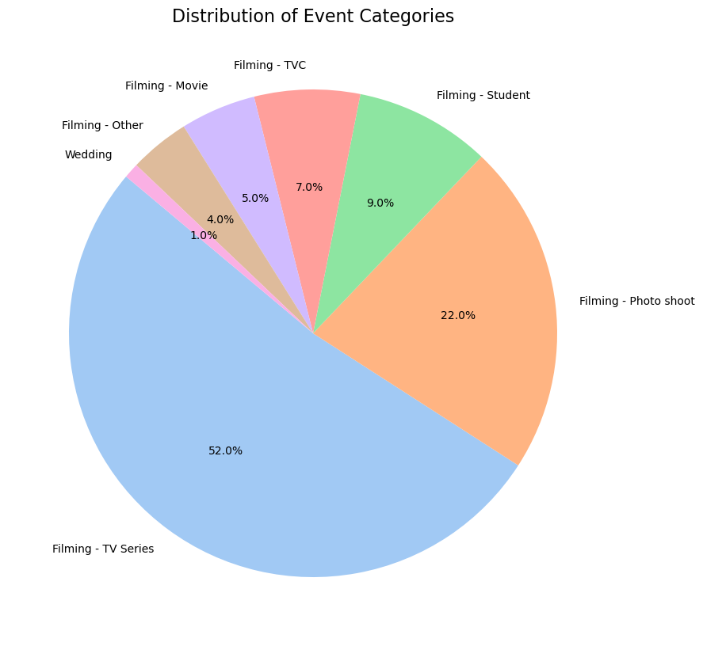

```python
plt.figure(figsize=(10, 10))
df_permits['category_1'].value_counts().plot.pie(autopct='%1.1f%%', startangle=140, colors=sns.color_palette('pastel'))
plt.title('Distribution of Event Categories', fontsize=16)
plt.ylabel('')  # Removing the y-label for a cleaner look
plt.show()
```

In this step, I create an interactive map using the folium library, centered on Melbourne. I loop through the df_artworks dataset and add markers for each artwork location using the latitude and longitude columns. Each marker includes a popup that displays the title of the artwork. This map allows for easy visualization of where artworks are located across Melbourne.

```python
import folium

# Create a folium map centered on Melbourne (approximate coordinates)
melbourne_map = folium.Map(location=[-37.8136, 144.9631], zoom_start=12)

# Assuming 'latitude' and 'longitude' are columns in df_artworks,
# add markers for each artwork location
for index, row in df_artworks.iterrows():
    folium.Marker(
        location=[row['longitude'], row['latitude']],
        popup=row['title'],  # Show title on popup
    ).add_to(melbourne_map)

melbourne_map
```

Make this Notebook Trusted to load map: File -> Trust Notebook

[interactive chart not shown]

In this code, I use matplotlib and seaborn to create a scatter plot that visualizes the locations of photogenic areas in Melbourne based on their latitude and longitude. The plot uses blue markers with black edges for better visibility, and titles, labels, and gridlines are added for clarity and aesthetics. This helps to easily identify the spatial distribution of these areas across the city.

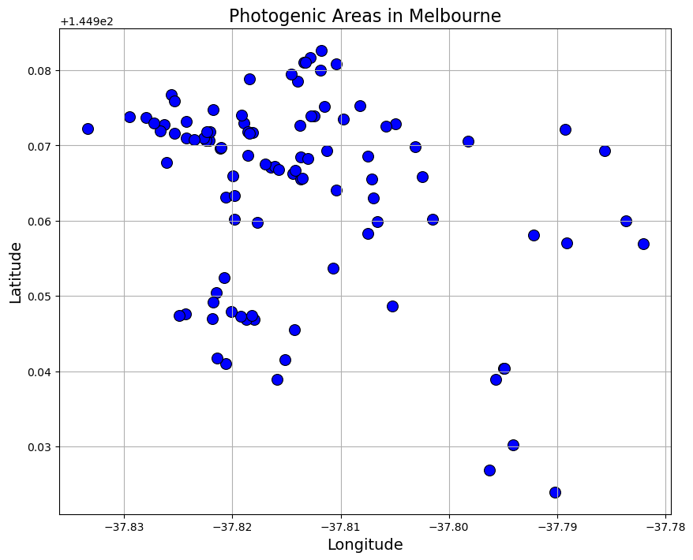

```python
import matplotlib.pyplot as plt
import seaborn as sns

# Plot the locations
plt.figure(figsize=(10, 8))
sns.scatterplot(x='longitude', y='latitude', data=coordinates, marker='o', s=100, color='blue', edgecolor='black')

# Add titles and labels
plt.title('Photogenic Areas in Melbourne', fontsize=16)
plt.xlabel('Longitude', fontsize=14)
plt.ylabel('Latitude', fontsize=14)

# Improve aesthetics
plt.grid(True)
plt.show()
```